# Machine Learning Project

Obed Otto C.

21 June 2015

The objective of the project is to predict, How well a person is doing barbell lifts. As given in the assignment question output(classe variable) needs to be predicted using accelerometers on the belt, forearm, arm, and dumbell of 6 participants.

```r
set.seed(4234);
```

The required packages are loaded as follows.

```r
library(caret);
library(kernlab);
library(ggplot2);
library(rattle);
library(rpart);
library(gbm);
```

Given training and test sets are loaded as follows

```r
testing<-read.csv("pml-testing.csv");
training<-read.csv("pml-training.csv");
```

Required predictor variables are stored as given below.

```r
reqvar_train<-c("user_name","accel_belt_x","accel_belt_y","accel_belt_z","accel_arm_x","accel_arm_y","accel_arm_z","accel_dumbbell_x","accel_dumbbell_y","accel_dumbbell_z","accel_forearm_x","accel_forearm_y","accel_forearm_z","classe");

reqvar_test<-c("user_name","accel_belt_x","accel_belt_y","accel_belt_z","accel_arm_x","accel_arm_y","accel_arm_z","accel_dumbbell_x","accel_dumbbell_y","accel_dumbbell_z","accel_forearm_x","accel_forearm_y","accel_forearm_z");
```

New training and test sets are formed based on the predictors. All the unwanted variables are removed from the training and testing data.

```r
training1<-training[,reqvar_train];
testing1<-testing[,reqvar_test];
```

Near zero values need to be removed before training. Identification of near zero values are done as follows.

```r
nsv<-nearZeroVar(training1,saveMetrics=TRUE);
print(nsv)
```

```
##                  freqRatio percentUnique zeroVar   nzv
## user_name         1.100679    0.03057792   FALSE FALSE
## accel_belt_x      1.055412    0.83579655   FALSE FALSE
## accel_belt_y      1.113725    0.72877383   FALSE FALSE
## accel_belt_z      1.078767    1.52379982   FALSE FALSE
## accel_arm_x       1.017341    3.95984099   FALSE FALSE
## accel_arm_y       1.140187    2.73672409   FALSE FALSE
## accel_arm_z       1.128000    4.03628580   FALSE FALSE
## accel_dumbbell_x  1.018018    2.16593619   FALSE FALSE
## accel_dumbbell_y  1.053061    2.37488533   FALSE FALSE
## accel_dumbbell_z  1.133333    2.08949139   FALSE FALSE
## accel_forearm_x   1.126437    4.04647844   FALSE FALSE
## accel_forearm_y   1.059406    5.11160942   FALSE FALSE
## accel_forearm_z   1.006250    2.95586586   FALSE FALSE
## classe            1.469581    0.02548160   FALSE FALSE
```

In the above table,in nzv column all the records are having FALSE. Which means there is no near zero values. If any of the value is true, the corresponding variable needs to be removed.

Since our aim is to predict, How well a person is doing barbell lifts, I have separated each person’s training data separately and one model is created for each person. When new data comes, output will be predicted using the corresponding person’s model.

The separation of individual person’s(Example user name:“eurico” ) training data is done as follows and also user_name is not used for training

```r
dataeurico1<-subset(training1,user_name=="eurico")
dataeurico<-dataeurico1[,-1];
inTraineurico<-createDataPartition(y=dataeurico$classe,p=0.7,list=FALSE);
trainingeurico<-dataeurico[inTraineurico,];
testingeurico<-dataeurico[-inTraineurico,];
```

Feature plot for few of the parameters are as follows

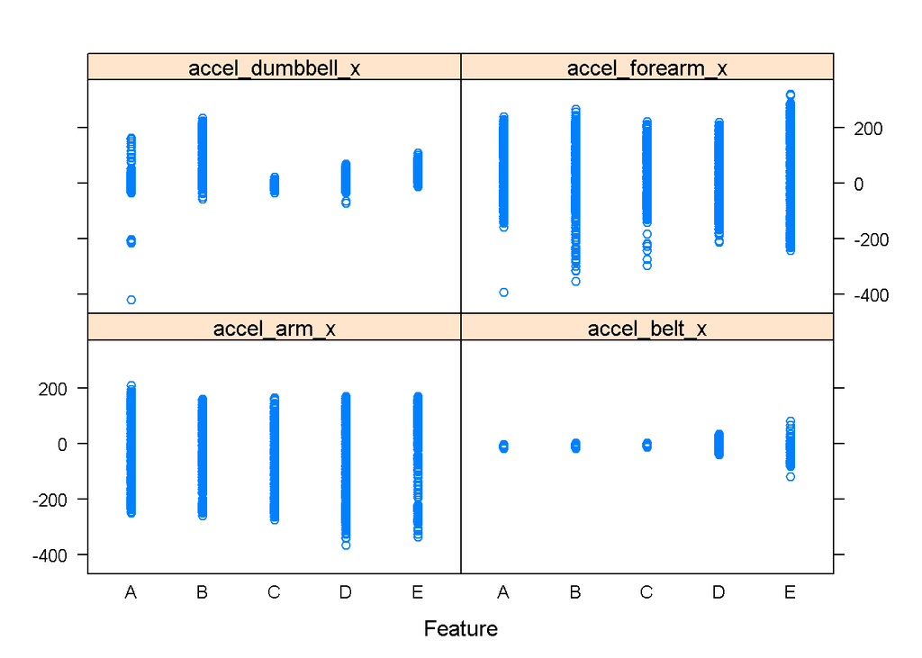

```r
featurePlot(x=trainingeurico[,c("accel_belt_x","accel_arm_x","accel_dumbbell_x","accel_forearm_x")],y=trainingeurico$classe)
```

K fold cross validation with K=8 is used

```r
fitControl <- trainControl(method = "repeatedcv",number = 10,repeats = 10)
```

```r
fitControl <- trainControl(method = "repeatedcv",number = 8,repeats = 8)

modelFiteurico<-train(classe~.,data=trainingeurico,preProcess=c("center","scale"),trControl = fitControl,method="gbm",verbose=FALSE);
outeurico<-predict(modelFiteurico,newdata=testingeurico);
confusionMatrix(testingeurico$classe,outeurico)
```

```
## Confusion Matrix and Statistics
##
##           Reference
## Prediction   A   B   C   D   E
##          A 254   3   2   0   0
##          B   2 172   2   0   1
##          C   3   4 139   0   0
##          D   2   0   0 169   3
##          E   1   0   0   4 157
##
## Overall Statistics
##
##                Accuracy : 0.9706
##                  95% CI : (0.9575, 0.9805)
##     No Information Rate : 0.2854
##     P-Value [Acc > NIR] : < 2.2e-16
##
##                   Kappa : 0.9628
##  Mcnemar's Test P-Value : NA
##
## Statistics by Class:
##
##                      Class: A Class: B Class: C Class: D Class: E
## Sensitivity            0.9695   0.9609   0.9720   0.9769   0.9752
## Specificity            0.9924   0.9932   0.9910   0.9933   0.9934
## Pos Pred Value         0.9807   0.9718   0.9521   0.9713   0.9691
## Neg Pred Value         0.9879   0.9906   0.9948   0.9946   0.9947
## Prevalence             0.2854   0.1950   0.1558   0.1885   0.1754
## Detection Rate         0.2767   0.1874   0.1514   0.1841   0.1710
## Detection Prevalence   0.2821   0.1928   0.1590   0.1895   0.1765
## Balanced Accuracy      0.9809   0.9771   0.9815   0.9851   0.9843
```

```r
classeeurico<-predict(modelFiteurico,testing1[16,]);
print(classeeurico)
```

```
## [1] E
## Levels: A B C D E
```